# Exercise 06

Author

Hubert Rehrauer

Published

October 24, 2022

## Comparison of Expression Estimates

The data set consists for 3 Normal samples and 3 Treated samples with 2.5 Mio reads each. The reads are simulated to come from genes on the human chromosome 1.

The expression values from featureCounts were created with: We use the library `Rsubread` to generate the counts

```r
library(Rsubread)
countResult1 = featureCounts(..., strandSpecific=0,
                                 GTF.featureType="exon", GTF.attrType="gene_id", useMetaFeatures=TRUE,
                                 allowMultiOverlap=TRUE, countMultiMappingReads=FALSE)
save(countResult1, file="countResult1.RData")
countResult2 = featureCounts(..., strandSpecific=0,
                                 GTF.featureType="exon", GTF.attrType="gene_id", useMetaFeatures=TRUE,
                                 allowMultiOverlap=TRUE, countMultiMappingReads=TRUE, fraction=TRUE)
save(countResult2, file="countResult2.RData")
```

The RSEM data were generated with

```bash
rsem-calculate-expression .... --calc-pme --calc-ci --strandedness none ...
```

For documentation see: http://deweylab.github.io/RSEM/rsem-calculate-expression.html

## Exercises

```r
#Packages
library(miceadds)
library(tidyverse)
```

```r
#Readin data

#featureCounts data
countResults1 = load.Rdata2("countResult1.RData", path = getwd())
countResults2 = load.Rdata2("countResult2.RData", path = getwd())

#RSEM genedata
RSEM_N1_genes <-read.table("RSEM_counts/N1.genes.results", header=TRUE, sep= "\t")
RSEM_N2_genes <-read.table("RSEM_counts/N2.genes.results", header=TRUE, sep= "\t")
RSEM_N3_genes <-read.table("RSEM_counts/N3.genes.results", header=TRUE, sep= "\t")
RSEM_T1_genes <-read.table("RSEM_counts/T1.genes.results", header=TRUE, sep= "\t")
RSEM_T2_genes <-read.table("RSEM_counts/T2.genes.results", header=TRUE, sep= "\t")
RSEM_T3_genes <-read.table("RSEM_counts/T3.genes.results", header=TRUE, sep= "\t")

#RSEM isoforms
RSEM_N1_isoforms <-read.table("RSEM_counts/N1.isoforms.results", header=TRUE, sep= "\t")
RSEM_N2_isoforms <-read.table("RSEM_counts/N2.isoforms.results", header=TRUE, sep= "\t")
RSEM_N3_isoforms <-read.table("RSEM_counts/N3.isoforms.results", header=TRUE, sep= "\t")
RSEM_T1_isoforms <-read.table("RSEM_counts/T1.isoforms.results", header=TRUE, sep= "\t")
RSEM_T2_isoforms <-read.table("RSEM_counts/T2.isoforms.results", header=TRUE, sep= "\t")
RSEM_T3_isoforms <-read.table("RSEM_counts/T3.isoforms.results", header=TRUE, sep= "\t")
```

## 1. Depending on the featureCount mode, how many alignments are ignored during counting?

There are the two featureCount modes countResults1 and countResults2 where the difference was whether multi-mapped reads were counted for or not. We need to get the ignored algnements for both of them.

```r
#Get ignored alignements during counting
ig_al_1 <- sum(countResults1$stat[-1,-1])
ig_al_2 <- sum(countResults2$stat[-1,-1])
```

```r
#ignored alignements during counting for countResults1
ig_al_1
```

```
[1] 419830
```

The number of ignored alignements during counting for countResults1 which is not multi-mapped is: 419830

```r
#ignored alignements during counting for countResults2
ig_al_2
```

```
[1] 35519
```

The number of ignored alignements during counting for countResults2 with multipmapping is: 35519

## 2. Compare the counts from featureCounts with the genelevel counts from RSEM. Which genes have different values?

```r
#Get feautureCounts

featureCounts1 <- countResults1$counts %>%
  as.data.frame() %>%
  rownames_to_column(var = "gene_id") %>%
  arrange(gene_id)

featureCounts2 <- countResults2$counts %>%
  as.data.frame() %>%
  rownames_to_column(var = "gene_id") %>%
  arrange(gene_id)

head(featureCounts1)
```

```
          gene_id STAR_mapped.N1.bam STAR_mapped.N2.bam STAR_mapped.N3.bam
1 ENSG00000000457                402                595                606
2 ENSG00000000460                252                351                323
3 ENSG00000000938                378                901                629
4 ENSG00000000971              11776              14273              16969
5 ENSG00000001460                219                252                681
6 ENSG00000001461               2166               1286               1599
  STAR_mapped.T1.bam STAR_mapped.T2.bam STAR_mapped.T3.bam
1                517                552                465
2                342                345                323
3                654                458                258
4              12234              10342              15956
5                 84                 58                 35
6               1765               2012               1461
```

```r
head(featureCounts2)
```

```
          gene_id STAR_mapped.N1.bam STAR_mapped.N2.bam STAR_mapped.N3.bam
1 ENSG00000000457             404.00             597.00             608.00
2 ENSG00000000460             254.00             353.00             325.00
3 ENSG00000000938             378.00             901.00             629.00
4 ENSG00000000971           12145.41           14709.75           17503.75
5 ENSG00000001460             222.00             253.00             684.00
6 ENSG00000001461            2171.00            1289.00            1602.00
  STAR_mapped.T1.bam STAR_mapped.T2.bam STAR_mapped.T3.bam
1             521.50             554.50             468.50
2             345.00             347.00             325.00
3             654.00             459.00             258.50
4           12614.41           10655.75           16470.75
5              84.00              58.00              35.00
6            1773.00            2018.50            1464.00
```

```r
#Get Gene counts
RSEM_gene_counts <- RSEM_N1_genes[,c("gene_id", "expected_count")] %>%
  left_join(RSEM_N2_genes[,c("gene_id", "expected_count")], by = "gene_id", suffix = c(".N1", ".N2")) %>%
  left_join(RSEM_N3_genes[,c("gene_id", "expected_count")], by = "gene_id") %>%
  left_join(RSEM_T1_genes[,c("gene_id", "expected_count")], by = "gene_id", suffix = c(".N3", ".T1")) %>%
  left_join(RSEM_T2_genes[,c("gene_id", "expected_count")], by = "gene_id") %>%
  left_join(RSEM_T3_genes[,c("gene_id", "expected_count")], by = "gene_id", suffix = c("T2", ".T3")) %>%
  arrange(gene_id)

head(RSEM_gene_counts)
```

```
          gene_id expected_count.N1 expected_count.N2 expected_count.N3
1 ENSG00000000457            353.00            537.67            549.23
2 ENSG00000000460            128.00            157.33            148.77
3 ENSG00000000938            363.00            864.00            605.00
4 ENSG00000000971          11643.28          14096.30          16792.28
5 ENSG00000001460            153.00            212.00            632.00
6 ENSG00000001461           2114.00           1235.00           1552.00
  expected_count.T1 expected_countT2 expected_count.T3
1            479.56           496.05            416.88
2            157.44           175.95            166.12
3            616.00           433.00            244.00
4          12097.49         10209.64          15788.52
5             23.00             8.00              0.00
6           1727.00          1954.00           1432.00
```

```r
# Get genes with different values in the featureCounts and the genelevel for countResults1

Gene_IDs <- RSEM_gene_counts["gene_id"]

#Get difference in expression between
diff_ex1 = RSEM_gene_counts[, -1] - featureCounts1[, -1]

#Remove the ones without any difference
indx_rm1 = which(apply(diff_ex1, 1, function(x) all(x == 0)) )
diff_Gen1 = Gene_IDs[ -indx_rm1, ]

# Top differently expressed genes
head(diff_Gen1)
```

```
[1] "ENSG00000000457" "ENSG00000000460" "ENSG00000000938" "ENSG00000000971"
[5] "ENSG00000001460" "ENSG00000001461"
```

```r
#Number of differently expressed genes
len_diff1<-length(diff_Gen1)
len_diff1
```

```
[1] 2582
```

Comparing the RSEM gene counts and the featureCounts alignments for countResults1, there are 2582 genes with different values in at least one sample.

```r
# Get genes with different values in the featureCounts and the genelevel for countResults2

#Get difference in expression between
diff_ex2 = RSEM_gene_counts[, -1] - featureCounts2[, -1]

#Remove the ones without any difference
indx_rm2 = which(apply(diff_ex2, 1, function(x) all(x == 0)) )
diff_Gen2 = Gene_IDs[ -indx_rm2, ]

# Top differentaily expressed genes
head(diff_Gen2)
```

```
[1] "ENSG00000000457" "ENSG00000000460" "ENSG00000000938" "ENSG00000000971"
[5] "ENSG00000001460" "ENSG00000001461"
```

```r
#Number of differently expressed genes
len_diff2<-length(diff_Gen2)
len_diff2
```

```
[1] 2838
```

Comparing the RSEM gene counts and the featureCounts alignments for countResults2, there are 2838 genes with different values in at least one sample.

## 3. How does the sum of the counts in RSEM compare to the number of the aligned reads?

```r
#Get counts in RSEM
RSEM_isoform_counts <- RSEM_N1_isoforms[,c("transcript_id", "expected_count")] %>%
  left_join(RSEM_N2_isoforms[,c("transcript_id", "expected_count")], by = "transcript_id", suffix = c(".N1", ".N2"))%>%
  left_join(RSEM_N3_isoforms[,c("transcript_id", "expected_count")], by = "transcript_id") %>%
  left_join(RSEM_T1_isoforms[,c("transcript_id", "expected_count")], by = "transcript_id", suffix = c(".N3", ".T1")) %>%
  left_join(RSEM_T2_isoforms[,c("transcript_id", "expected_count")], by = "transcript_id") %>%
  left_join(RSEM_T3_isoforms[,c("transcript_id", "expected_count")], by = "transcript_id", suffix = c("T2", ".T3"))

head(RSEM_isoform_counts)
```

```
    transcript_id expected_count.N1 expected_count.N2 expected_count.N3
1 ENST00000367770             56.00              0.00              0.00
2 ENST00000367771            206.03            388.02            403.36
3 ENST00000367772             68.12            132.35            135.06
4 ENST00000423670              0.00              7.08              0.00
5 ENST00000470238             22.85             10.22             10.81
6 ENST00000286031              0.00              0.00             10.37
  expected_count.T1 expected_countT2 expected_count.T3
1              0.00             0.00              0.00
2            342.94           370.43            349.00
3            131.35           101.10             67.88
4              0.00             0.00              0.00
5              5.27            24.52              0.00
6              0.00             9.15              9.25
```

```r
#Get the sum of the counts in RSEM
colSums(RSEM_gene_counts[, -1])
```

```
expected_count.N1 expected_count.N2 expected_count.N3 expected_count.T1
          2410621           2411935           2411696           2412459
 expected_countT2 expected_count.T3
          2410414           2412864
```

```r
#Number of the aligned reads of countResults1
countResults1$stat[1,-1]
```

```
  STAR_mapped.N1.bam STAR_mapped.N2.bam STAR_mapped.N3.bam STAR_mapped.T1.bam
1            2476971            2475323            2474827            2455326
  STAR_mapped.T2.bam STAR_mapped.T3.bam
1            2463833            2463489
```

```r
#Number of the aligned reads of countResults2
countResults2$stat[1,-1]
```

```
  STAR_mapped.N1.bam STAR_mapped.N2.bam STAR_mapped.N3.bam STAR_mapped.T1.bam
1            2524127            2526106            2527485            2541426
  STAR_mapped.T2.bam STAR_mapped.T3.bam
1            2537585            2537351
```

The sum of the counts in RSEM is closer to the number of the aligned reads of countResults1 which had no multipmapping than countResults2 with the multipmapping.

## 4. Compute pair-wise correlation of the samples based on the isoform counts and gene level counts

```r
#Get pairwise correlation between gene counts
gen_cor <- cor(RSEM_gene_counts[, -1])
gen_cor
```

```
                  expected_count.N1 expected_count.N2 expected_count.N3
expected_count.N1         1.0000000         0.9223265         0.8525764
expected_count.N2         0.9223265         1.0000000         0.9306585
expected_count.N3         0.8525764         0.9306585         1.0000000
expected_count.T1         0.2015782         0.2440927         0.2785407
expected_countT2          0.2139167         0.2630601         0.2988457
expected_count.T3         0.2206943         0.2741199         0.3053998
                  expected_count.T1 expected_countT2 expected_count.T3
expected_count.N1         0.2015782        0.2139167         0.2206943
expected_count.N2         0.2440927        0.2630601         0.2741199
expected_count.N3         0.2785407        0.2988457         0.3053998
expected_count.T1         1.0000000        0.9294959         0.8685437
expected_countT2          0.9294959        1.0000000         0.8431366
expected_count.T3         0.8685437        0.8431366         1.0000000
```

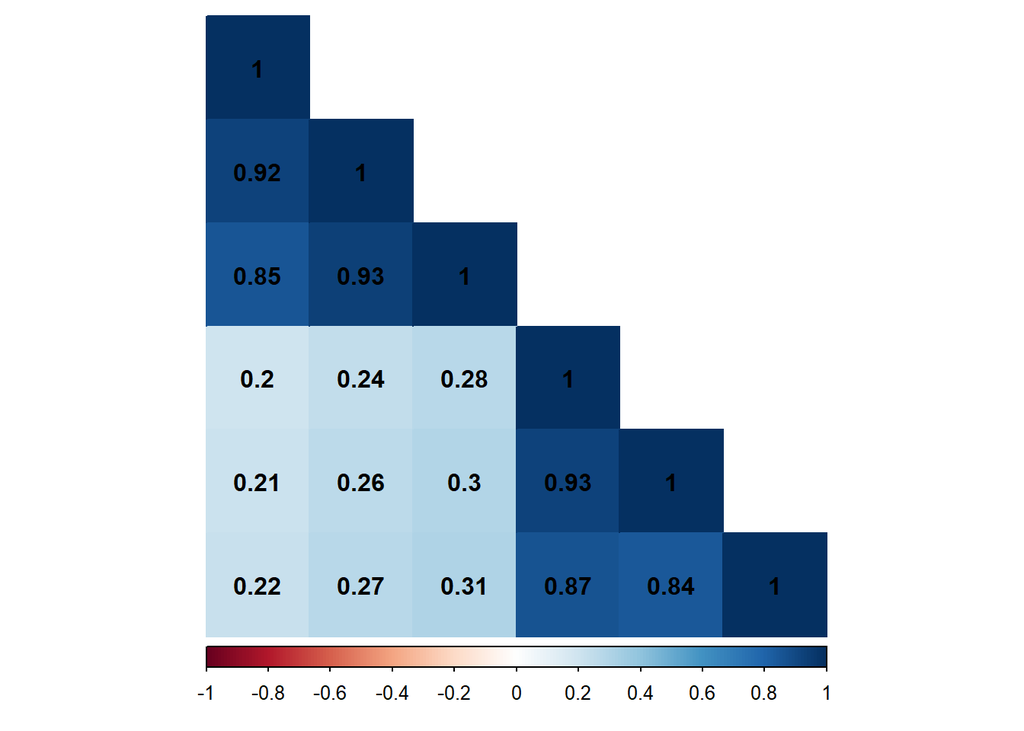

```r
corrplot::corrplot(gen_cor, method = "color", type = 'lower', diag = TRUE, tl.pos='n',addCoef.col = 'black')
```

```r
#Get pairwise correlation between isoform counts
isoform_cor <- cor(RSEM_isoform_counts[, -1])
isoform_cor
```

```
                  expected_count.N1 expected_count.N2 expected_count.N3
expected_count.N1         1.0000000         0.9150221         0.8400634
expected_count.N2         0.9150221         1.0000000         0.9209995
expected_count.N3         0.8400634         0.9209995         1.0000000
expected_count.T1         0.1526188         0.1773515         0.2100433
expected_countT2          0.1601697         0.1875532         0.2201798
expected_count.T3         0.1478623         0.1675725         0.1921782
                  expected_count.T1 expected_countT2 expected_count.T3
expected_count.N1         0.1526188        0.1601697         0.1478623
expected_count.N2         0.1773515        0.1875532         0.1675725
expected_count.N3         0.2100433        0.2201798         0.1921782
expected_count.T1         1.0000000        0.9210393         0.8611534
expected_countT2          0.9210393        1.0000000         0.8322041
expected_count.T3         0.8611534        0.8322041         1.0000000
```

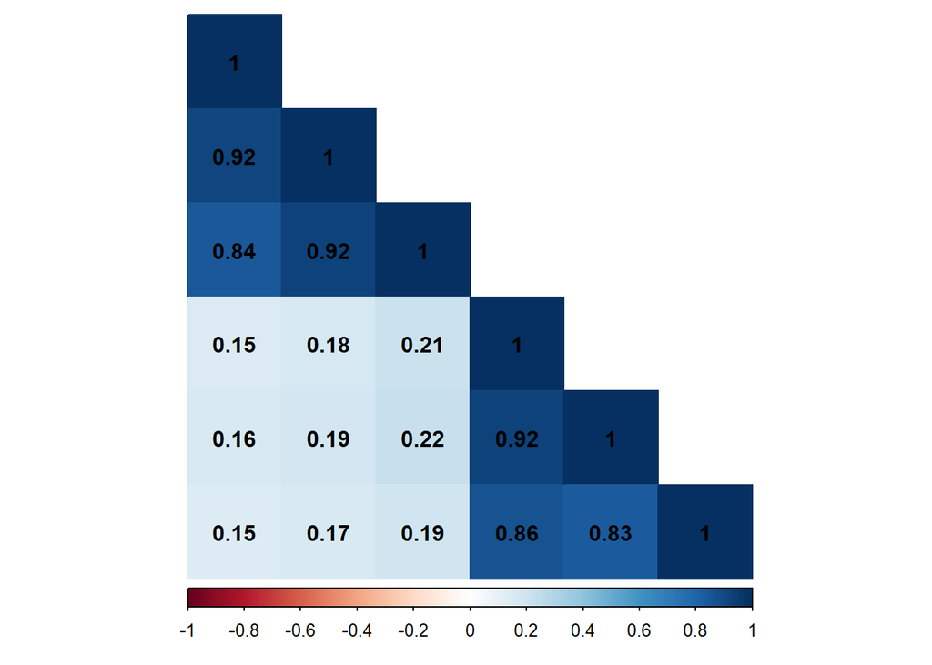

```r
corrplot::corrplot(isoform_cor, method = "color", type = 'lower', diag = TRUE, tl.pos='n',addCoef.col = 'black')
```